```python
import pandas as pd
import numpy as np
import matplotlib.pyplot as plt
import seaborn as sns
import sys
print(sys.executable)
```

```
C:\Users\USER\miniconda3\envs\myenv\python.exe
```

# Load the two datasets

```python
import sys
!{sys.executable} -m pip install openpyxl
```

```python
transactions = pd.read_excel('QVI_transaction_data.xlsx')
customers = pd.read_csv('QVI_purchase_behaviour.csv')
```

```python
transactions.info()
```

```
<class 'pandas.DataFrame'>
RangeIndex: 264836 entries, 0 to 264835
Data columns (total 8 columns):
 #   Column          Non-Null Count   Dtype
---  ------          --------------   -----
 0   DATE            264836 non-null  int64
 1   STORE_NBR       264836 non-null  int64
 2   LYLTY_CARD_NBR  264836 non-null  int64
 3   TXN_ID          264836 non-null  int64
 4   PROD_NBR        264836 non-null  int64
 5   PROD_NAME       264836 non-null  str
 6   PROD_QTY        264836 non-null  int64
 7   TOT_SALES       264836 non-null  float64
dtypes: float64(1), int64(6), str(1)
memory usage: 16.2 MB
```

```python
transactions.describe()
```

|  | DATE | STORE_NBR | LYLTY_CARD_NBR | TXN_ID | PROD_NBR | PROD_QTY | TOT_SALES |
| --- | --- | --- | --- | --- | --- | --- | --- |
| count | 264836.000000 | 264836.00000 | 2.648360e+05 | 2.648360e+05 | 264836.000000 | 264836.000000 | 264836.000000 |
| mean | 43464.036260 | 135.08011 | 1.355495e+05 | 1.351583e+05 | 56.583157 | 1.907309 | 7.304200 |
| std | 105.389282 | 76.78418 | 8.057998e+04 | 7.813303e+04 | 32.826638 | 0.643654 | 3.083226 |
| min | 43282.000000 | 1.00000 | 1.000000e+03 | 1.000000e+00 | 1.000000 | 1.000000 | 1.500000 |
| 25% | 43373.000000 | 70.00000 | 7.002100e+04 | 6.760150e+04 | 28.000000 | 2.000000 | 5.400000 |
| 50% | 43464.000000 | 130.00000 | 1.303575e+05 | 1.351375e+05 | 56.000000 | 2.000000 | 7.400000 |
| 75% | 43555.000000 | 203.00000 | 2.030942e+05 | 2.027012e+05 | 85.000000 | 2.000000 | 9.200000 |
| max | 43646.000000 | 272.00000 | 2.373711e+06 | 2.415841e+06 | 114.000000 | 200.000000 | 650.000000 |

```python
print(transactions.shape)
transactions.info()
```

```
(264836, 8)
<class 'pandas.DataFrame'>
RangeIndex: 264836 entries, 0 to 264835
Data columns (total 8 columns):
 #   Column          Non-Null Count   Dtype
---  ------          --------------   -----
 0   DATE            264836 non-null  int64
 1   STORE_NBR       264836 non-null  int64
 2   LYLTY_CARD_NBR  264836 non-null  int64
 3   TXN_ID          264836 non-null  int64
 4   PROD_NBR        264836 non-null  int64
 5   PROD_NAME       264836 non-null  str
 6   PROD_QTY        264836 non-null  int64
 7   TOT_SALES       264836 non-null  float64
dtypes: float64(1), int64(6), str(1)
memory usage: 16.2 MB
```

```python
# identifing data anomalies and flagged outlier
transactions[transactions['PROD_QTY'] == 200]
```

|  | DATE | STORE_NBR | LYLTY_CARD_NBR | TXN_ID | PROD_NBR | PROD_NAME | PROD_QTY | TOT_SALES |
| --- | --- | --- | --- | --- | --- | --- | --- | --- |
| 69762 | 43331 | 226 | 226000 | 226201 | 4 | Dorito Corn Chp Supreme 380g | 200 | 650.0 |
| 69763 | 43605 | 226 | 226000 | 226210 | 4 | Dorito Corn Chp Supreme 380g | 200 | 650.0 |

```python
# identifing data anomalies and flagged outlier
transactions[transactions['LYLTY_CARD_NBR'] == 226000]
```

|  | DATE | STORE_NBR | LYLTY_CARD_NBR | TXN_ID | PROD_NBR | PROD_NAME | PROD_QTY | TOT_SALES |
| --- | --- | --- | --- | --- | --- | --- | --- | --- |
| 69762 | 43331 | 226 | 226000 | 226201 | 4 | Dorito Corn Chp Supreme 380g | 200 | 650.0 |
| 69763 | 43605 | 226 | 226000 | 226210 | 4 | Dorito Corn Chp Supreme 380g | 200 | 650.0 |

```python
#removing commercial transactions
transactions = transactions[transactions['LYLTY_CARD_NBR'] != 226000]

# Confirm it's gone
print(transactions[transactions['LYLTY_CARD_NBR'] == 226000])
print(transactions.shape)
```

```
Empty DataFrame
Columns: [DATE, STORE_NBR, LYLTY_CARD_NBR, TXN_ID, PROD_NBR, PROD_NAME, PROD_QTY, TOT_SALES]
Index: []
(264834, 8)
```

```python
#covert excel serial number to actual date
transactions['DATE'] = pd.to_datetime(transactions['DATE'], origin='1899-12-30', unit='D')
transactions['DATE'].head()
```

```
0   2018-10-17
1   2019-05-14
2   2019-05-20
3   2018-08-17
4   2018-08-18
Name: DATE, dtype: datetime64[s]
```

```python
print(transactions['DATE'].min())
print(transactions['DATE'].max())
print((transactions['DATE'].max() - transactions['DATE'].min()).days + 1)
print(transactions['DATE'].nunique())
```

```
2018-07-01 00:00:00
2019-06-30 00:00:00
365
364
```

```python
# identifying unique date
all_dates = pd.date_range(start=transactions['DATE'].min(), end=transactions['DATE'].max())
missing_dates = all_dates[~all_dates.isin(transactions['DATE'])]
missing_dates
```

```
DatetimeIndex(['2018-12-25'], dtype='datetime64[s]', freq='D')
```

```python
#checking product name
pd.set_option('display.max_rows', None)
transactions['PROD_NAME'].unique()
```

```
<StringArray>
[  'Natural Chip        Compny SeaSalt175g',
                 'CCs Nacho Cheese    175g',
   'Smiths Crinkle Cut  Chips Chicken 170g',
   'Smiths Chip Thinly  S/Cream&Onion 175g',
 'Kettle Tortilla ChpsHny&Jlpno Chili 150g',
 'Old El Paso Salsa   Dip Tomato Mild 300g',
 'Smiths Crinkle Chips Salt & Vinegar 330g',
    'Grain Waves         Sweet Chilli 210g',
  'Doritos Corn Chip Mexican Jalapeno 150g',
    'Grain Waves Sour    Cream&Chives 210G',
 ...
         'Doritos Cheese      Supreme 330g',
      'Smiths Crinkle Cut  Snag&Sauce 150g',
   'WW Sour Cream &OnionStacked Chips 160g',
                 'RRD Lime & Pepper   165g',
   'Natural ChipCo Sea  Salt & Vinegr 175g',
    'Red Rock Deli Chikn&Garlic Aioli 150g',
      'RRD SR Slow Rst     Pork Belly 150g',
                 'RRD Pc Sea Salt     165g',
       'Smith Crinkle Cut   Bolognese 150g',
                 'Doritos Salsa Mild  300g']
Length: 114, dtype: str
```

```python
transactions[transactions['PROD_NAME'].str.contains('salsa|dip', case=False)]['PROD_NAME'].unique()
```

```
<StringArray>
['Old El Paso Salsa   Dip Tomato Mild 300g',
 'Red Rock Deli SR    Salsa & Mzzrlla 150g',
 'Smiths Crinkle Cut  French OnionDip 150g',
    'Smiths Crinkle Cut  Tomato Salsa 150g',
          'Doritos Salsa       Medium 300g',
 'Old El Paso Salsa   Dip Chnky Tom Ht300g',
           'Woolworths Mild     Salsa 300g',
  'Old El Paso Salsa   Dip Tomato Med 300g',
           'Woolworths Medium   Salsa 300g',
                 'Doritos Salsa Mild  300g']
Length: 10, dtype: str
```

```python
transactions[transactions['PROD_NAME'].str.contains('French OnionDip', case=False)]['PROD_NAME'].unique()
```

```
<StringArray>
['Smiths Crinkle Cut  French OnionDip 150g']
Length: 1, dtype: str
```

```python
transactions = transactions[~transactions['PROD_NAME'].str.contains('salsa', case=False)]

# Confirm removal
print(transactions[transactions['PROD_NAME'].str.contains('salsa', case=False)])
print(transactions.shape)
print(transactions['PROD_NAME'].nunique())
```

```
Empty DataFrame
Columns: [DATE, STORE_NBR, LYLTY_CARD_NBR, TXN_ID, PROD_NBR, PROD_NAME, PROD_QTY, TOT_SALES]
Index: []
(246740, 8)
105
```

```python
transactions[transactions['PROD_NAME'].str.extract(r'(\d+)g')[0].isna()]['PROD_NAME'].unique()
```

```
<StringArray>
[   'Grain Waves Sour    Cream&Chives 210G',
  'Red Rock Deli Sp    Salt & Truffle 150G',
 'Smiths Thinly       Swt Chli&S/Cream175G']
Length: 3, dtype: str
```

```python
transactions['PACK_SIZE'] = transactions['PROD_NAME'].str.extract(r'(\d+)[gG]')[0].astype(int)
transactions['PACK_SIZE'].describe()
```

```
count    246740.000000
mean        175.583521
std          59.432118
min          70.000000
25%         150.000000
50%         170.000000
75%         175.000000
max         380.000000
Name: PACK_SIZE, dtype: float64
```

```python
transactions['BRAND'] = transactions['PROD_NAME'].str.split().str[0]
transactions['BRAND'].value_counts()
```

```
BRAND
Kettle        41288
Smiths        27390
Pringles      25102
Doritos       22041
Thins         14075
RRD           11894
Infuzions     11057
WW            10320
Cobs           9693
Tostitos       9471
Twisties       9454
Tyrrells       6442
Grain          6272
Natural        6050
Cheezels       4603
CCs            4551
Red            4427
Dorito         3183
Infzns         3144
Smith          2963
Cheetos        2927
Snbts          1576
Burger         1564
Woolworths     1516
GrnWves        1468
Sunbites       1432
NCC            1419
French         1418
Name: count, dtype: int64
```

```python
transactions[transactions['BRAND'].isin(['French', 'Burger'])]['PROD_NAME'].unique()
```

```
<StringArray>
['Burger Rings 220g', 'French Fries Potato Chips 175g']
Length: 2, dtype: str
```

# fixes for the real duplicates

```python
#fixes for the real duplicates
brand_fixes = {
    'Dorito': 'Doritos',
    'Smith': 'Smiths',
    'Infzns': 'Infuzions',
    'Grain': 'Grain Waves',
    'GrnWves': 'Grain Waves',
    'RRD': 'Red Rock Deli',
    'Red': 'Red Rock Deli',
    'WW': 'Woolworths',
    'Snbts': 'Sunbites',
    'NCC': 'Natural Chip Co'
}
transactions['BRAND'] = transactions['BRAND'].replace(brand_fixes)
transactions['BRAND'].value_counts()
```

```
BRAND
Kettle             41288
Smiths             30353
Doritos            25224
Pringles           25102
Red Rock Deli      16321
Infuzions          14201
Thins              14075
Woolworths         11836
Cobs                9693
Tostitos            9471
Twisties            9454
Grain Waves         7740
Tyrrells            6442
Natural             6050
Cheezels            4603
CCs                 4551
Sunbites            3008
Cheetos             2927
Burger              1564
Natural Chip Co     1419
French              1418
Name: count, dtype: int64
```

```python
transactions[transactions['BRAND'].isin(['Natural', 'Natural Chip Co'])]['PROD_NAME'].unique()
```

```
<StringArray>
[ 'Natural Chip        Compny SeaSalt175g',
  'NCC Sour Cream &    Garden Chives 175g',
  'Natural ChipCo      Hony Soy Chckn175g',
 'Natural Chip Co     Tmato Hrb&Spce 175g',
  'Natural ChipCo Sea  Salt & Vinegr 175g']
Length: 5, dtype: str
```

```python
transactions['BRAND'] = transactions['BRAND'].replace({'Natural': 'Natural Chip Co'})
transactions['BRAND'].value_counts()
```

```
BRAND
Kettle             41288
Smiths             30353
Doritos            25224
Pringles           25102
Red Rock Deli      16321
Infuzions          14201
Thins              14075
Woolworths         11836
Cobs                9693
Tostitos            9471
Twisties            9454
Grain Waves         7740
Natural Chip Co     7469
Tyrrells            6442
Cheezels            4603
CCs                 4551
Sunbites            3008
Cheetos             2927
Burger              1564
French              1418
Name: count, dtype: int64
```

```python
transactions[['STORE_NBR', 'LYLTY_CARD_NBR', 'TXN_ID']].describe()
```

|  | STORE_NBR | LYLTY_CARD_NBR | TXN_ID |
| --- | --- | --- | --- |
| count | 246740.000000 | 2.467400e+05 | 2.467400e+05 |
| mean | 135.050361 | 1.355303e+05 | 1.351304e+05 |
| std | 76.786971 | 8.071520e+04 | 7.814760e+04 |
| min | 1.000000 | 1.000000e+03 | 1.000000e+00 |
| 25% | 70.000000 | 7.001500e+04 | 6.756875e+04 |
| 50% | 130.000000 | 1.303670e+05 | 1.351815e+05 |
| 75% | 203.000000 | 2.030832e+05 | 2.026522e+05 |
| max | 272.000000 | 2.373711e+06 | 2.415841e+06 |

```python
transactions.to_csv('QVI_transaction_data_clean.csv', index=False)
print("Saved!")
transactions.shape
```

```
Saved!
```

```
(246740, 10)
```

```python
customers.info()
customers.describe(include='all')
```

```
<class 'pandas.DataFrame'>
RangeIndex: 72637 entries, 0 to 72636
Data columns (total 3 columns):
 #   Column            Non-Null Count  Dtype
---  ------            --------------  -----
 0   LYLTY_CARD_NBR    72637 non-null  int64
 1   LIFESTAGE         72637 non-null  str
 2   PREMIUM_CUSTOMER  72637 non-null  str
dtypes: int64(1), str(2)
memory usage: 1.7 MB
```

|  | LYLTY_CARD_NBR | LIFESTAGE | PREMIUM_CUSTOMER |
| --- | --- | --- | --- |
| count | 7.263700e+04 | 72637 | 72637 |
| unique | NaN | 7 | 3 |
| top | NaN | RETIREES | Mainstream |
| freq | NaN | 14805 | 29245 |
| mean | 1.361859e+05 | NaN | NaN |
| std | 8.989293e+04 | NaN | NaN |
| min | 1.000000e+03 | NaN | NaN |
| 25% | 6.620200e+04 | NaN | NaN |
| 50% | 1.340400e+05 | NaN | NaN |
| 75% | 2.033750e+05 | NaN | NaN |
| max | 2.373711e+06 | NaN | NaN |

```python
customers['LYLTY_CARD_NBR'].duplicated().sum()
```

```
np.int64(0)
```

# Now let's join the two datasets.

```python
merged_data = transactions.merge(customers, on='LYLTY_CARD_NBR', how='left')
merged_data.head()
print(merged_data.shape)
merged_data.isnull().sum()
```

```
(246740, 12)
```

```
DATE                0
STORE_NBR           0
LYLTY_CARD_NBR      0
TXN_ID              0
PROD_NBR            0
PROD_NAME           0
PROD_QTY            0
TOT_SALES           0
PACK_SIZE           0
BRAND               0
LIFESTAGE           0
PREMIUM_CUSTOMER    0
dtype: int64
```

```python
merged_data.to_csv('QVI_merged_data.csv', index=False)
print("Saved!")
merged_data.shape
```

```
Saved!
```

```
(246740, 12)
```

# Data analysis and customer segments

```python
sales_by_segment = merged_data.groupby(['LIFESTAGE', 'PREMIUM_CUSTOMER'])['TOT_SALES'].sum().reset_index()
sales_by_segment = sales_by_segment.sort_values('TOT_SALES', ascending=False)
sales_by_segment
```

|  | LIFESTAGE | PREMIUM_CUSTOMER | TOT_SALES |
| --- | --- | --- | --- |
| 6 | OLDER FAMILIES | Budget | 156863.75 |
| 19 | YOUNG SINGLES/COUPLES | Mainstream | 147582.20 |
| 13 | RETIREES | Mainstream | 145168.95 |
| 15 | YOUNG FAMILIES | Budget | 129717.95 |
| 9 | OLDER SINGLES/COUPLES | Budget | 127833.60 |
| 10 | OLDER SINGLES/COUPLES | Mainstream | 124648.50 |
| 11 | OLDER SINGLES/COUPLES | Premium | 123537.55 |
| 12 | RETIREES | Budget | 105916.30 |
| 7 | OLDER FAMILIES | Mainstream | 96413.55 |
| 14 | RETIREES | Premium | 91296.65 |
| 16 | YOUNG FAMILIES | Mainstream | 86338.25 |
| 1 | MIDAGE SINGLES/COUPLES | Mainstream | 84734.25 |
| 17 | YOUNG FAMILIES | Premium | 78571.70 |
| 8 | OLDER FAMILIES | Premium | 75242.60 |
| 18 | YOUNG SINGLES/COUPLES | Budget | 57122.10 |
| 2 | MIDAGE SINGLES/COUPLES | Premium | 54443.85 |
| 20 | YOUNG SINGLES/COUPLES | Premium | 39052.30 |
| 0 | MIDAGE SINGLES/COUPLES | Budget | 33345.70 |
| 3 | NEW FAMILIES | Budget | 20607.45 |
| 4 | NEW FAMILIES | Mainstream | 15979.70 |
| 5 | NEW FAMILIES | Premium | 10760.80 |

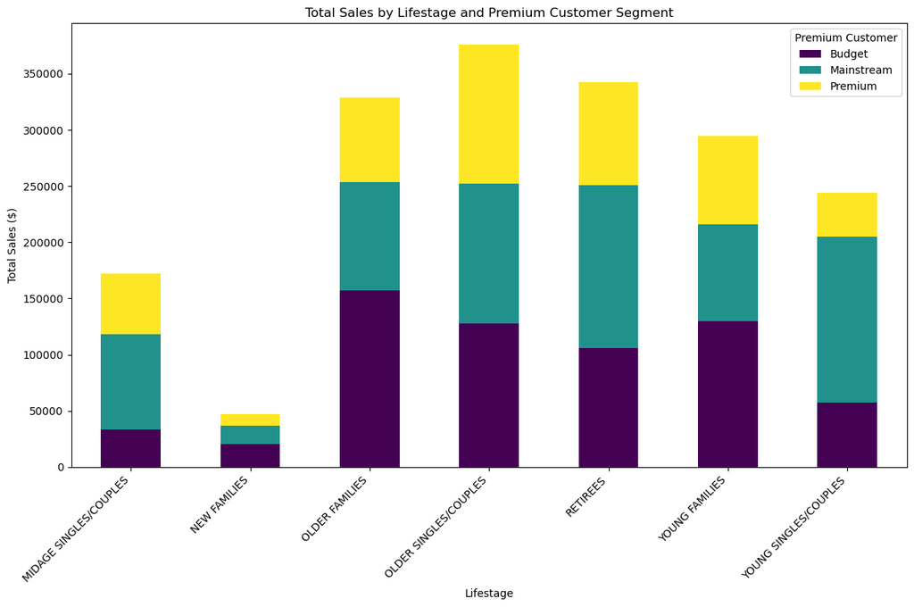

```python
plt.figure(figsize=(12, 8))
pivot = merged_data.groupby(['LIFESTAGE', 'PREMIUM_CUSTOMER'])['TOT_SALES'].sum().unstack()
pivot.plot(kind='bar', stacked=True, figsize=(12, 8), colormap='viridis')
plt.title('Total Sales by Lifestage and Premium Customer Segment')
plt.xlabel('Lifestage')
plt.ylabel('Total Sales ($)')
plt.xticks(rotation=45, ha='right')
plt.legend(title='Premium Customer')
plt.tight_layout()
plt.savefig('sales_by_segment.png', dpi=150)
plt.show()
```

```python
customer_counts = merged_data.groupby(['LIFESTAGE', 'PREMIUM_CUSTOMER'])['LYLTY_CARD_NBR'].nunique().reset_index()
customer_counts.columns = ['LIFESTAGE', 'PREMIUM_CUSTOMER', 'CUSTOMER_COUNT']

segment_summary = sales_by_segment.merge(customer_counts, on=['LIFESTAGE', 'PREMIUM_CUSTOMER'])
segment_summary['AVG_SALES_PER_CUSTOMER'] = segment_summary['TOT_SALES'] / segment_summary['CUSTOMER_COUNT']
segment_summary = segment_summary.sort_values('AVG_SALES_PER_CUSTOMER', ascending=False)
segment_summary
```

|  | LIFESTAGE | PREMIUM_CUSTOMER | TOT_SALES | CUSTOMER_COUNT | AVG_SALES_PER_CUSTOMER |
| --- | --- | --- | --- | --- | --- |
| 8 | OLDER FAMILIES | Mainstream | 96413.55 | 2788 | 34.581618 |
| 0 | OLDER FAMILIES | Budget | 156863.75 | 4611 | 34.019464 |
| 13 | OLDER FAMILIES | Premium | 75242.60 | 2231 | 33.725952 |
| 3 | YOUNG FAMILIES | Budget | 129717.95 | 3953 | 32.815065 |
| 12 | YOUNG FAMILIES | Premium | 78571.70 | 2398 | 32.765513 |
| 10 | YOUNG FAMILIES | Mainstream | 86338.25 | 2685 | 32.155773 |
| 6 | OLDER SINGLES/COUPLES | Premium | 123537.55 | 4682 | 26.385636 |
| 4 | OLDER SINGLES/COUPLES | Budget | 127833.60 | 4849 | 26.362879 |
| 11 | MIDAGE SINGLES/COUPLES | Mainstream | 84734.25 | 3298 | 25.692617 |
| 5 | OLDER SINGLES/COUPLES | Mainstream | 124648.50 | 4858 | 25.658399 |
| 7 | RETIREES | Budget | 105916.30 | 4385 | 24.154230 |
| 9 | RETIREES | Premium | 91296.65 | 3812 | 23.949803 |
| 15 | MIDAGE SINGLES/COUPLES | Premium | 54443.85 | 2369 | 22.981786 |
| 2 | RETIREES | Mainstream | 145168.95 | 6358 | 22.832487 |
| 17 | MIDAGE SINGLES/COUPLES | Budget | 33345.70 | 1474 | 22.622592 |
| 19 | NEW FAMILIES | Mainstream | 15979.70 | 830 | 19.252651 |
| 18 | NEW FAMILIES | Budget | 20607.45 | 1087 | 18.958096 |
| 20 | NEW FAMILIES | Premium | 10760.80 | 575 | 18.714435 |
| 1 | YOUNG SINGLES/COUPLES | Mainstream | 147582.20 | 7917 | 18.641177 |
| 16 | YOUNG SINGLES/COUPLES | Premium | 39052.30 | 2480 | 15.746895 |
| 14 | YOUNG SINGLES/COUPLES | Budget | 57122.10 | 3647 | 15.662764 |

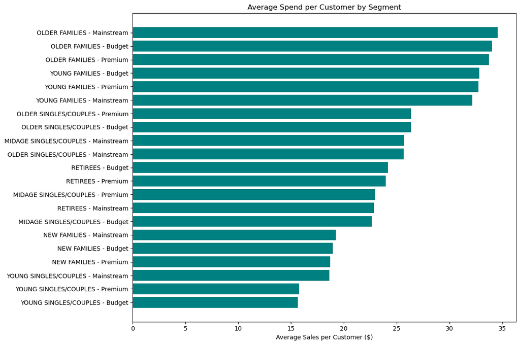

```python
plt.figure(figsize=(12, 8))
segment_summary_sorted = segment_summary.sort_values('AVG_SALES_PER_CUSTOMER', ascending=True)
plt.barh(segment_summary_sorted['LIFESTAGE'] + ' - ' + segment_summary_sorted['PREMIUM_CUSTOMER'],
         segment_summary_sorted['AVG_SALES_PER_CUSTOMER'], color='teal')
plt.xlabel('Average Sales per Customer ($)')
plt.title('Average Spend per Customer by Segment')
plt.tight_layout()
plt.savefig('avg_spend_per_customer.png', dpi=150)
plt.show()
```

```python
units_per_customer = merged_data.groupby(['LIFESTAGE', 'PREMIUM_CUSTOMER']).agg(
    TOTAL_UNITS=('PROD_QTY', 'sum'),
    CUSTOMERS=('LYLTY_CARD_NBR', 'nunique')
).reset_index()
units_per_customer['AVG_UNITS_PER_CUSTOMER'] = units_per_customer['TOTAL_UNITS'] / units_per_customer['CUSTOMERS']
units_per_customer.sort_values('AVG_UNITS_PER_CUSTOMER', ascending=False)
```

|  | LIFESTAGE | PREMIUM_CUSTOMER | TOTAL_UNITS | CUSTOMERS | AVG_UNITS_PER_CUSTOMER |
| --- | --- | --- | --- | --- | --- |
| 7 | OLDER FAMILIES | Mainstream | 25804 | 2788 | 9.255380 |
| 6 | OLDER FAMILIES | Budget | 41853 | 4611 | 9.076773 |
| 8 | OLDER FAMILIES | Premium | 20239 | 2231 | 9.071717 |
| 15 | YOUNG FAMILIES | Budget | 34482 | 3953 | 8.722995 |
| 17 | YOUNG FAMILIES | Premium | 20901 | 2398 | 8.716013 |
| 16 | YOUNG FAMILIES | Mainstream | 23194 | 2685 | 8.638361 |
| 9 | OLDER SINGLES/COUPLES | Budget | 32883 | 4849 | 6.781398 |
| 11 | OLDER SINGLES/COUPLES | Premium | 31695 | 4682 | 6.769543 |
| 10 | OLDER SINGLES/COUPLES | Mainstream | 32607 | 4858 | 6.712021 |
| 1 | MIDAGE SINGLES/COUPLES | Mainstream | 21213 | 3298 | 6.432080 |
| 12 | RETIREES | Budget | 26932 | 4385 | 6.141847 |
| 14 | RETIREES | Premium | 23266 | 3812 | 6.103358 |
| 2 | MIDAGE SINGLES/COUPLES | Premium | 14400 | 2369 | 6.078514 |
| 0 | MIDAGE SINGLES/COUPLES | Budget | 8883 | 1474 | 6.026459 |
| 13 | RETIREES | Mainstream | 37677 | 6358 | 5.925920 |
| 4 | NEW FAMILIES | Mainstream | 4060 | 830 | 4.891566 |
| 3 | NEW FAMILIES | Budget | 5241 | 1087 | 4.821527 |
| 5 | NEW FAMILIES | Premium | 2769 | 575 | 4.815652 |
| 19 | YOUNG SINGLES/COUPLES | Mainstream | 36225 | 7917 | 4.575597 |
| 20 | YOUNG SINGLES/COUPLES | Premium | 10575 | 2480 | 4.264113 |
| 18 | YOUNG SINGLES/COUPLES | Budget | 15500 | 3647 | 4.250069 |

```python
#pack size
pack_by_segment = merged_data.groupby(['LIFESTAGE', 'PREMIUM_CUSTOMER'])['PACK_SIZE'].mean().reset_index()
pack_by_segment = pack_by_segment.sort_values('PACK_SIZE', ascending=False)
pack_by_segment
```

|  | LIFESTAGE | PREMIUM_CUSTOMER | PACK_SIZE |
| --- | --- | --- | --- |
| 19 | YOUNG SINGLES/COUPLES | Mainstream | 178.344249 |
| 1 | MIDAGE SINGLES/COUPLES | Mainstream | 177.898693 |
| 11 | OLDER SINGLES/COUPLES | Premium | 176.485568 |
| 12 | RETIREES | Budget | 176.395641 |
| 14 | RETIREES | Premium | 176.368421 |
| 4 | NEW FAMILIES | Mainstream | 175.629748 |
| 6 | OLDER FAMILIES | Budget | 175.546342 |
| 15 | YOUNG FAMILIES | Budget | 175.459720 |
| 9 | OLDER SINGLES/COUPLES | Budget | 175.334673 |
| 5 | NEW FAMILIES | Premium | 175.245296 |
| 13 | RETIREES | Mainstream | 175.213671 |
| 7 | OLDER FAMILIES | Mainstream | 175.175666 |
| 10 | OLDER SINGLES/COUPLES | Mainstream | 174.812145 |
| 3 | NEW FAMILIES | Budget | 174.766643 |
| 17 | YOUNG FAMILIES | Premium | 174.659032 |
| 2 | MIDAGE SINGLES/COUPLES | Premium | 174.585391 |
| 8 | OLDER FAMILIES | Premium | 174.524752 |
| 16 | YOUNG FAMILIES | Mainstream | 174.202059 |
| 0 | MIDAGE SINGLES/COUPLES | Budget | 174.182690 |
| 20 | YOUNG SINGLES/COUPLES | Premium | 174.002563 |
| 18 | YOUNG SINGLES/COUPLES | Budget | 173.378981 |

```python
most_common_pack = merged_data.groupby(['LIFESTAGE', 'PREMIUM_CUSTOMER'])['PACK_SIZE'].agg(lambda x: x.mode()[0]).reset_index()
most_common_pack.columns = ['LIFESTAGE', 'PREMIUM_CUSTOMER', 'MOST_COMMON_PACK_SIZE']
most_common_pack
```

|  | LIFESTAGE | PREMIUM_CUSTOMER | MOST_COMMON_PACK_SIZE |
| --- | --- | --- | --- |
| 0 | MIDAGE SINGLES/COUPLES | Budget | 175 |
| 1 | MIDAGE SINGLES/COUPLES | Mainstream | 175 |
| 2 | MIDAGE SINGLES/COUPLES | Premium | 175 |
| 3 | NEW FAMILIES | Budget | 175 |
| 4 | NEW FAMILIES | Mainstream | 175 |
| 5 | NEW FAMILIES | Premium | 175 |
| 6 | OLDER FAMILIES | Budget | 175 |
| 7 | OLDER FAMILIES | Mainstream | 175 |
| 8 | OLDER FAMILIES | Premium | 175 |
| 9 | OLDER SINGLES/COUPLES | Budget | 175 |
| 10 | OLDER SINGLES/COUPLES | Mainstream | 175 |
| 11 | OLDER SINGLES/COUPLES | Premium | 175 |
| 12 | RETIREES | Budget | 175 |
| 13 | RETIREES | Mainstream | 175 |
| 14 | RETIREES | Premium | 175 |
| 15 | YOUNG FAMILIES | Budget | 175 |
| 16 | YOUNG FAMILIES | Mainstream | 175 |
| 17 | YOUNG FAMILIES | Premium | 175 |
| 18 | YOUNG SINGLES/COUPLES | Budget | 175 |
| 19 | YOUNG SINGLES/COUPLES | Mainstream | 175 |
| 20 | YOUNG SINGLES/COUPLES | Premium | 175 |

```python
top_brand_by_segment = merged_data.groupby(['LIFESTAGE', 'PREMIUM_CUSTOMER', 'BRAND'])['TOT_SALES'].sum().reset_index()
top_brand_by_segment = top_brand_by_segment.sort_values('TOT_SALES', ascending=False).groupby(['LIFESTAGE', 'PREMIUM_CUSTOMER']).first()
top_brand_by_segment
```

| LIFESTAGE | PREMIUM_CUSTOMER | BRAND | TOT_SALES |
| --- | --- | --- | --- |
| MIDAGE SINGLES/COUPLES | Budget | Kettle | 6736.2 |
|  | Mainstream | Kettle | 20231.8 |
|  | Premium | Kettle | 11390.2 |
| NEW FAMILIES | Budget | Kettle | 4731.6 |
|  | Mainstream | Kettle | 3847.0 |
|  | Premium | Kettle | 2267.6 |
| OLDER FAMILIES | Budget | Kettle | 32058.0 |
|  | Mainstream | Kettle | 19420.2 |
|  | Premium | Kettle | 14505.8 |
| OLDER SINGLES/COUPLES | Budget | Kettle | 29066.4 |
|  | Mainstream | Kettle | 26852.8 |
|  | Premium | Kettle | 27943.4 |
| RETIREES | Budget | Kettle | 24340.0 |
|  | Mainstream | Kettle | 31652.4 |
|  | Premium | Kettle | 20922.4 |
| YOUNG FAMILIES | Budget | Kettle | 26369.6 |
|  | Mainstream | Kettle | 17049.2 |
|  | Premium | Kettle | 16614.2 |
| YOUNG SINGLES/COUPLES | Budget | Kettle | 11106.0 |
|  | Mainstream | Kettle | 35423.6 |
|  | Premium | Kettle | 7711.4 |

```python
target_segment = merged_data[merged_data['LIFESTAGE'] == 'OLDER FAMILIES']
other_segments = merged_data[merged_data['LIFESTAGE'] != 'OLDER FAMILIES']

target_brand_share = target_segment['BRAND'].value_counts(normalize=True)
other_brand_share = other_segments['BRAND'].value_counts(normalize=True)

brand_affinity = (target_brand_share / other_brand_share).sort_values(ascending=False)
brand_affinity
```

```
BRAND
Burger             1.301211
Woolworths         1.262207
Red Rock Deli      1.260126
Natural Chip Co    1.189018
Cheetos            1.187420
Sunbites           1.163689
CCs                1.163589
Smiths             1.131513
French             1.113032
Grain Waves        1.010767
Cheezels           0.957565
Thins              0.952433
Infuzions          0.951898
Twisties           0.939654
Tyrrells           0.912147
Pringles           0.908280
Cobs               0.898428
Doritos            0.896355
Kettle             0.888067
Tostitos           0.870818
Name: proportion, dtype: float64
```

```python
target_pack_share = target_segment['PACK_SIZE'].value_counts(normalize=True)
other_pack_share = other_segments['PACK_SIZE'].value_counts(normalize=True)

pack_affinity = (target_pack_share / other_pack_share).sort_values(ascending=False)
pack_affinity.head(10)
```

```
PACK_SIZE
180    1.340364
220    1.301211
200    1.273758
190    1.242202
160    1.221263
90     1.163689
70     1.160770
125    1.145883
165    1.093095
150    1.015365
Name: proportion, dtype: float64
```

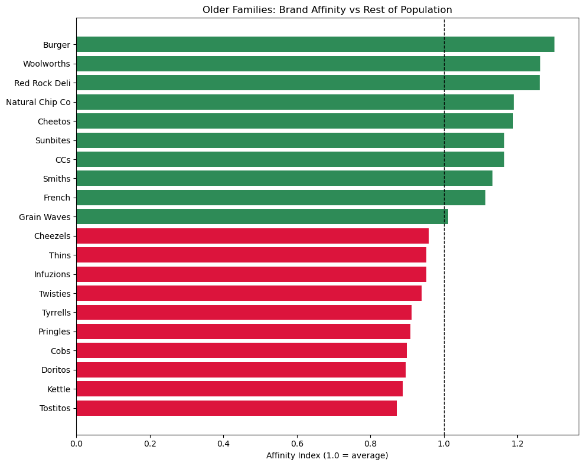

```python
plt.figure(figsize=(10, 8))
brand_affinity_sorted = brand_affinity.sort_values()
colors = ['crimson' if x < 1 else 'seagreen' for x in brand_affinity_sorted]
plt.barh(brand_affinity_sorted.index, brand_affinity_sorted.values, color=colors)
plt.axvline(x=1, color='black', linestyle='--', linewidth=1)
plt.xlabel('Affinity Index (1.0 = average)')
plt.title('Older Families: Brand Affinity vs Rest of Population')
plt.tight_layout()
plt.savefig('older_families_brand_affinity.png', dpi=150)
plt.show()
```

```python
target_segment2 = merged_data[merged_data['LIFESTAGE'] == 'YOUNG FAMILIES']
other_segments2 = merged_data[merged_data['LIFESTAGE'] != 'YOUNG FAMILIES']

target_brand_share2 = target_segment2['BRAND'].value_counts(normalize=True)
other_brand_share2 = other_segments2['BRAND'].value_counts(normalize=True)

brand_affinity2 = (target_brand_share2 / other_brand_share2).sort_values(ascending=False)
brand_affinity2
```

```
BRAND
Sunbites           1.258531
CCs                1.252050
French             1.242038
Red Rock Deli      1.208064
Cheetos            1.178497
Burger             1.174132
Woolworths         1.169992
Natural Chip Co    1.141015
Smiths             1.101966
Cheezels           1.024764
Grain Waves        0.953959
Infuzions          0.941227
Thins              0.936483
Cobs               0.935431
Tostitos           0.933508
Tyrrells           0.932593
Doritos            0.929822
Pringles           0.916751
Kettle             0.913151
Twisties           0.894263
Name: proportion, dtype: float64
```

```python
sales_by_segment.to_csv('sales_by_segment.csv', index=False)
segment_summary.to_csv('segment_summary_avg_spend_units.csv', index=False)
pack_by_segment.to_csv('pack_size_by_segment.csv', index=False)
brand_affinity.to_csv('older_families_brand_affinity.csv', header=['affinity_index'])
brand_affinity2.to_csv('young_families_brand_affinity.csv', header=['affinity_index'])
print("All analysis files saved!")
```

```
All analysis files saved!
```

## Summary of Findings

**Highest total sales:** Older Families/Budget, Young Singles-Couples/Mainstream, Retirees/Mainstream — driven mainly by having large customer bases, not necessarily high per-customer value.

**Highest value customers:** Older and Young Families spend the most per customer (~$32–35) and buy the most units (~8.6–9.3 per customer) — nearly double that of Young Singles/Couples (~$15–19, ~4.3–4.6 units).

**Pack size:** Not a meaningful differentiator between segments — preference is fairly consistent across all groups (~173–178g average).

**Brand preference:** A meaningful differentiator — Families (both Older and Young) consistently favor value/everyday brands: Woolworths, Red Rock Deli, Sunbites, CCs, Natural Chip Co, Cheetos, Burger Rings — and consistently avoid premium/mainstream leaders like Kettle, Pringles, Doritos, Tostitos.

## Recommendation

```
Target marketing and promotions toward Families (Older and Young) as the highest-value segment on a per-customer basis, specifically promoting value-oriented, everyday snack brands (Woolworths, Red Rock Deli, Sunbites, CCs) rather than premium lines, since that's where their actual purchasing behavior already sits. Meanwhile, Young Singles/Couples remain a high-volume segment worth retaining, but with lower expected return per customer, so may warrant lower-cost engagement (e.g. digital/loyalty app promotions) rather than the same investment level as Families.
```

```python
import os
for f in os.listdir():
    if f.endswith('.csv') or f.endswith('.png'):
        print(f)
```

```
avg_spend_per_customer.png
EdTech.csv
heartdisease.csv
housing - housing.csv
older_families_brand_affinity.csv
older_families_brand_affinity.png
pack_size_by_segment.csv
QVI_merged_data.csv
QVI_purchase_behaviour.csv
QVI_transaction_data_clean.csv
sales_by_segment.csv
sales_by_segment.png
segment_summary_avg_spend_units.csv
young_families_brand_affinity.csv
```